# Flow Cytometry (FC) data characterized with Machine Learning (ML) approaches

## Objectives

1. Wrangle FC data in R
2. Use the TidyModels metapackage to apply ML algorithms to categorize samples based on sampling type

## What is flow cytometry?

The etimology of the word cyto:

<Greek kyto-, combining form of kýtos container, receptacle, body.

**Flow cytometry** is a technique that allows us to interrogate cell characteristics based on its light scattering and fluorescent properties.  
The characteristics that we can infer from cytometric data are:

- relative size,
- relative granularity or internal complexity, and
- relative fluorescence intensity.

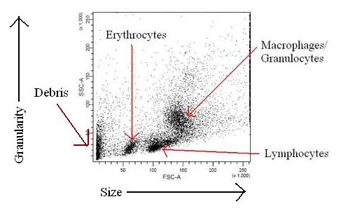

Annotated flow cytometry plot

Along the X-axis is the FSC (Forward SCatter) parameter: measurement of the amount of the laser beam that passes around the cell.  
With a control or standard, we could determine the relative size of the cells.

Along the Y-axis is the SSC (Side SCatter) parameter: measurement of the amount of the laser beam that bounces off of particulates inside of the cell. Any laser light of the same wavelength of the laser(488nm) that bounces off of things inside the cell is collected and recorded as SSC.

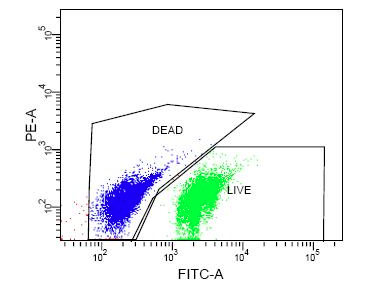

Gated live dead events (cells)

Syto-9 (and *SG*) stains the DNA of cells **indiscriminately**, while *PI* stains only the cells with a **compromised membrane**. With the two stains combined, only live cells are stained with syto-9, with only compromised (dead) cells staining with PI.

The technique relies on:

- Fluidics –> stream transporting particles to optic system.
- Optics –> lasers to illuminate and filters to direct to appropriate detectors.
- Electronics –> turn light signal into electronic signal that can be processed (e.g. emitted signal into electronic pulses).

## Step 1: Data collection

The data we’re about to use was generated from residential and commercial samples of tap water using flow cytometry.  
The stains used to quantify total cell counts and intact cell counts were SYBR Green (SG) and SG + Propidium Iodide (SGPI), respectively.

## Step 2: Load packages

Set up the right environment by importing the necessary libraries.

```r
#FC
library(flowCore) #https://rdrr.io/bioc/flowCore/f/inst/doc/HowTo-flowCore.pdf
library(flowViz)
library(ggcyto)

##ML
library(tidymodels)

#Data wrangling
library(tidyverse)
library(skimr)

#Aesthetics
library(ggtext)
library(patchwork)
library(gt)
```

### Formats

Aesthetics to be applied in the communication of results via plots.

```r
#Plot theme to apply throughout
my_theme<- theme_minimal(base_family = "Titillium Web") +
  theme(plot.title = element_markdown(face="bold"))
```

### Get data

Import FC data to R.

```r
flowData_C <- read.flowSet(path = "FC_data/COM_fcs/", pattern=".fcs") #Commercial
flowData_R <- read.flowSet(path = "FC_data/RES_fcs/", pattern=".fcs") #Residential
```

## Step 3: Explore data

When we import the data using `read.flowSet` function from `flowCore` package we pull from a directory containing FCS files and obtain an object of class `flowSet`.

**What is a flowSet class?**

Classes in `flowCore`

- flowFrame - a class representing the data contained in a FCS file.
1. raw measurement
2. keywords in the FCS files
3. annotation for parameters (stains, sample names, range)
- flowSet - a collection of flowFrame.

There are several options to work with a flowSet object, such as:

- [, [[, $ - subsetting
- sampleNames, colnames - names
- phenoData, pData - metadata
- fsApply - apply family, flowSet-specific iterator

```r
#Commercial
flowData_C # all experiments
```

```
## A flowSet with 5 experiments.
##
##   column names:
##   FSC-A SSC-A FL1-A FL2-A FL3-A FL4-A FSC-H SSC-H FL1-H FL2-H FL3-H FL4-H Width Time
```

```r
flowData_C[1] # experiment 1 (list), subsetting
```

```
## A flowSet with 1 experiments.
##
##   column names:
##   FSC-A SSC-A FL1-A FL2-A FL3-A FL4-A FSC-H SSC-H FL1-H FL2-H FL3-H FL4-H Width Time
```

```r
flowData_C[[1]] # features in experiment (data frame), subsetting
```

```
## flowFrame object 'B01 COM03_TCC_TP01_R1.fcs'
## with 10000 cells and 14 observables:
##       name    desc    range minRange maxRange
## $P1  FSC-A   FSC-A 16777216        0 16777215
## $P2  SSC-A   SSC-A 16777216        0 16777215
## $P3  FL1-A  FITC-A 16777216        0 16777215
## $P4  FL2-A    PE-A 16777216        0 16777215
## $P5  FL3-A PerCP-A 16777216        0 16777215
## $P6  FL4-A   APC-A 16777216        0 16777215
## $P7  FSC-H   FSC-H 16777216        0 16777215
## $P8  SSC-H   SSC-H 16777216        0 16777215
## $P9  FL1-H  FITC-H 16777216        0 16777215
## $P10 FL2-H    PE-H 16777216        0 16777215
## $P11 FL3-H PerCP-H 16777216        0 16777215
## $P12 FL4-H   APC-H 16777216        0 16777215
## $P13 Width   Width 16777216        0 16777215
## $P14  Time    Time 16777216        0 16777215
## 248 keywords are stored in the 'description' slot
```

```r
summary(flowData_C)
```

```
## $`B01 COM03_TCC_TP01_R1.fcs`
##               FSC-A       SSC-A      FL1-A       FL2-A       FL3-A      FL4-A
## Min.          0.000       0.000     438.00      89.000       0.000     0.0000
## 1st Qu.     289.750     493.000    1337.00    1469.000    1873.750   117.7500
## Median      783.000    1125.000    5244.00    2757.000    3165.000   387.0000
## Mean       5692.392    3149.865   10085.43    4490.002    6342.333   455.3967
## 3rd Qu.    2281.250    2231.250   12552.50    4960.500    5732.500   649.0000
## Max.    1206501.000 1009750.000 2409171.00 1580618.000 4587996.000 21926.0000
##               FSC-H       SSC-H      FL1-H      FL2-H      FL3-H      FL4-H
## Min.          0.000       0.000    800.000    103.000      0.000     0.0000
## 1st Qu.    1021.000    2530.000   1555.750   1683.750   2165.000   238.7500
## Median     1815.000    3558.500   5607.000   2888.000   3623.500   418.0000
## Mean       8272.242    6409.564   9957.452   4263.998   6255.255   527.9988
## 3rd Qu.    4261.000    5158.500  12856.500   5003.250   6502.000   675.0000
## Max.    1731147.000 1411107.000 759449.000 249333.000 759843.000 16573.0000
##            Width     Time
## Min.     17.0000 137.0000
## 1st Qu.  33.0000 202.0000
## Median   50.0000 269.0000
## Mean     48.9597 269.1776
## 3rd Qu.  63.0000 336.0000
## Max.    287.0000 401.0000
##
## $`E01 COM04_TCC_TP01_R1.fcs`
##              FSC-A       SSC-A       FL1-A      FL2-A      FL3-A      FL4-A
## Min.          0.00       0.000     433.000     90.000      0.000     0.0000
## 1st Qu.     815.75     704.000     856.000   1217.000   2888.000    83.0000
## Median     2327.00    1683.000    1301.000   2139.500   5307.500   379.0000
## Mean      19249.44    5555.753    4215.436   3849.985   9143.982   499.2306
## 3rd Qu.    7832.00    4028.000    2503.250   3964.750   9607.000   687.2500
## Max.    3156187.00 1052594.000 1003517.000 321568.000 924544.000 30479.0000
##              FSC-H      SSC-H      FL1-H      FL2-H      FL3-H      FL4-H
## Min.          0.00       0.00    801.000    108.000      0.000     0.0000
## 1st Qu.    2112.00    2909.75   1060.000   1524.000   3847.000   233.0000
## Median     4525.50    4519.00   1508.000   2454.000   6556.500   499.0000
## Mean      26036.53   10433.36   4170.004   3888.012   9815.379   644.1679
## 3rd Qu.   12123.50    8290.75   2747.250   4200.000  10878.500   854.0000
## Max.    2598857.00 1488112.00 354538.000 260651.000 795556.000 28578.0000
##            Width     Time
## Min.     17.0000 138.0000
```

[output cut: 59 more lines]

```
## Max.    1996392.00 1156159.000 776562.000 308434.000 1130690.00 16205.000
##              FSC-H       SSC-H      FL1-H      FL2-H      FL3-H     FL4-H
## Min.          0.00       0.000    801.000    115.000      0.000     0.000
## 1st Qu.    1697.75    2709.000   1067.000   1566.000   3687.750   242.000
## Median     3729.50    4000.000   1544.500   2516.000   6381.500   498.000
## Mean      16608.46    7914.483   4223.163   3754.869   9328.683   632.775
## 3rd Qu.    9434.25    6619.000   2938.500   4203.000  10910.500   858.000
## Max.    2107120.00 1653849.000 314980.000 237705.000 908955.000 16055.000
##            Width     Time
## Min.     17.0000 138.0000
## 1st Qu.  28.0000 345.0000
## Median   34.0000 548.0000
## Mean     37.9222 546.6601
## 3rd Qu.  43.0000 746.0000
## Max.    353.0000 948.0000
```

```r
sampleNames(flowData_C)
```

```
## [1] "B01 COM03_TCC_TP01_R1.fcs" "E01 COM04_TCC_TP01_R1.fcs"
## [3] "F03 COM05_TCC_TP01_R1.fcs" "F10 COM01_TCC_TP01_R1.fcs"
## [5] "G12 COM02_TCC_TP01_R1.fcs"
```

```r
pData(flowData_C) #pheno data info stored in the flowSet
```

|  | name |
| --- | --- |
| B01 COM03_TCC_TP01_R1.fcs | B01 COM03_TCC_TP01_R1.fcs |
| E01 COM04_TCC_TP01_R1.fcs | E01 COM04_TCC_TP01_R1.fcs |
| F03 COM05_TCC_TP01_R1.fcs | F03 COM05_TCC_TP01_R1.fcs |
| F10 COM01_TCC_TP01_R1.fcs | F10 COM01_TCC_TP01_R1.fcs |
| G12 COM02_TCC_TP01_R1.fcs | G12 COM02_TCC_TP01_R1.fcs |

From listing the experiment, we can see 12 channels in total.

**What are they recording?**

- channels: FSC-A , SSC-A, FL1-A , FL2-A, FL3-A, FL4-A, FSC-H, SSC-H, FL1-H, FL2-H, FL3-H, FL4-H
- additional: Width, Time

We already touched upon a couple of them in the primer section. But to get a better idea, we need to look at the specs of the BD Acuri instrument and its laser configuration.

[figure not shown]

In our case this configuration is: 3 blue one red.

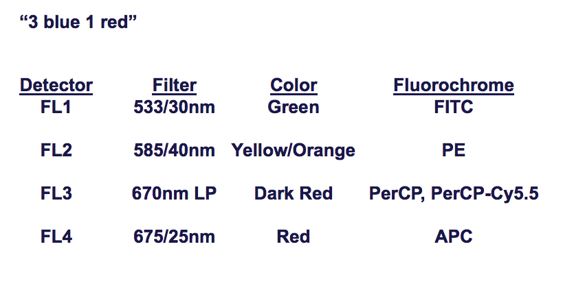

Characteristic/fluorescence relative to detector:

- G-FL (green fluorescence, FL1)
- R-FL (red fluorescence, FL3)
- Side-scattered light (SSC)
- Forward-scattered light (FSC)

### Channels

- A vs. H data  
  There are 6 paths each with a duplicate, totaling 12 channels. The “duplicates” are labeled A or H indicating that either area or **height** were measured for a given data.
- SSC  
  Side-scattered light shows the internal complexity or the granularity of a cell
- FSC Forward-scattered light indicates the relative size of the cell
- FL1 (green fluorescence)  
  Identifies the free microplasms. Allows the mycoplasma to be separated from the debris present
- FL3 (red fluorescence) Meant to distinguish the dead cells (non-viable cells)
- FL2 (yellow/orange fluorescence)  
  This can be used to discriminate between different cell types. For example, eukaryotic microalgae and cyanobacteria.
- FL4 (Red fluorescence)  
  This channel can be used to detect phycocyanin. There’s a variety of different applications for this channel, depending on staining combinations.

## Step 4a: Transform and select explanatory variables

**Why asinh?**

It improves the visualization of data with a low variance. Helps data to appear more normal by:

1. Allowing for negative values to be included
2. Providing a linear representation around 0
3. Smooth transition of values between extremes

There’s several transformations that can be applied to FC data. When tested against other transformations, it had a lower standard deviation and improved visualizations.

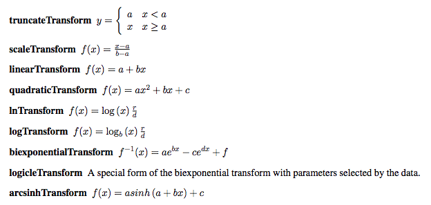

Tranformation formulae

```r
flowData_transformed_C <- transform(flowData_C,
                                    `FSC-A`=asinh(`FSC-A`),
                                    `SSC-A`=asinh(`SSC-A`),
                                    `FL1-A`=asinh(`FL1-A`),
                                    `FL2-A`=asinh(`FL2-A`),
                                    `FL3-A`=asinh(`FL3-A`),
                                    `FL4-A`=asinh(`FL4-A`),
                                    `FSC-H`=asinh(`FSC-H`),
                                    `SSC-H`=asinh(`SSC-H`),
                                    `FL1-H`=asinh(`FL1-H`),
                                    `FL2-H`=asinh(`FL2-H`),
                                    `FL3-H`=asinh(`FL3-H`),
                                    `FL4-H`=asinh(`FL4-H`)) #names correspond to fluorescent channel names

flowData_transformed_R <- transform(flowData_R,
                                    `FSC-A`=asinh(`FSC-A`),
                                    `SSC-A`=asinh(`SSC-A`),
                                    `FL1-A`=asinh(`FL1-A`),
                                    `FL2-A`=asinh(`FL2-A`),
                                    `FL3-A`=asinh(`FL3-A`),
                                    `FL4-A`=asinh(`FL4-A`),
                                    `FSC-H`=asinh(`FSC-H`),
                                    `SSC-H`=asinh(`SSC-H`),
                                    `FL1-H`=asinh(`FL1-H`),
                                    `FL2-H`=asinh(`FL2-H`),
                                    `FL3-H`=asinh(`FL3-H`),
                                    `FL4-H`=asinh(`FL4-H`)) #names correspond to fluorescent channel names

#param=c("FL1-H", "FL3-H","SSC-H","FSC-H")
```

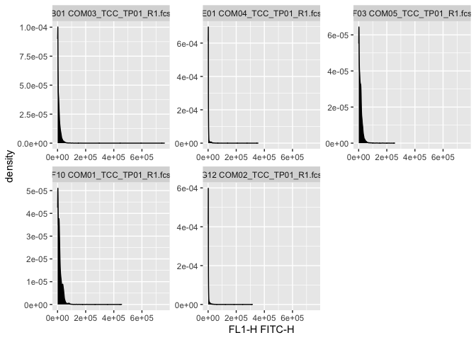

```r
#1d- density plot
ggcyto::autoplot(flowData_C, x = "FL1-H")
```

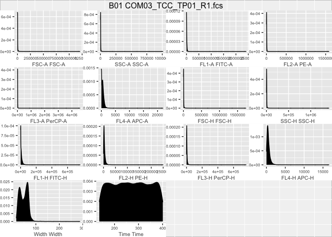

```r
#1d- density plot on all channels
ggcyto::autoplot(flowData_C[[1]])
```

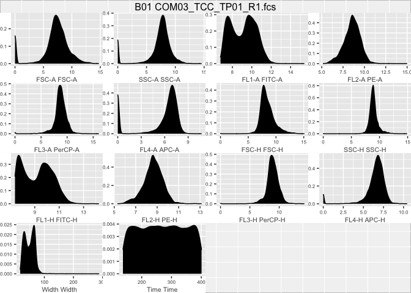

```r
ggcyto::autoplot(flowData_transformed_C[[1]])
```

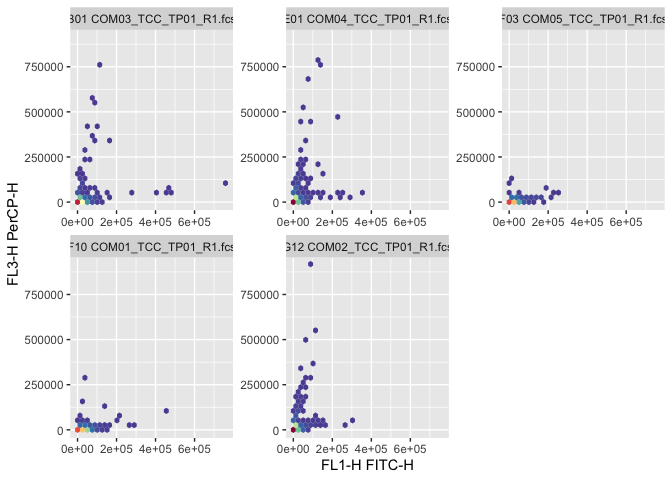

```r
#2d plot: default geom_hex plot
ggcyto::autoplot(flowData_C, "FL1-H", "FL3-H") #from ggcyto package
```

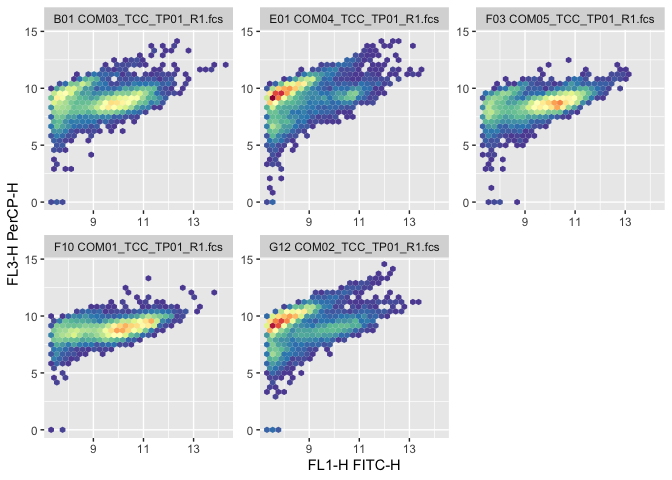

```r
ggcyto::autoplot(flowData_transformed_C, "FL1-H", "FL3-H")
```

## What is Machine Learning (ML)

Machine learning is a sub field of data science that aims at extracting (learning) patterns from data and applying them to evaluate a specific outcome (make educated guesses). The underlying algorithms apply complex statistics and math to fid patterns in large amount of data.

There are three major machine learning algorithm classes:

1. **Supervised learning**  
   - most used  
   - better understood  
   - data is labeled to tell the machine what patterns to look for  
   - the algorithm learns from input output pairs –> **supervised**
2. **Unsupervised learning**  
   - data has no labels - only the input data is known  
   - less obvious applications **Examples?**
3. **Reinforcement learning**  
   - trial and error approach to learning - rewards or penalties are given depending on how well it achieves a pre-defined goal

The properties that have been measured in the input data are called **features**. Often they are numerical vectors, but can be anything from strings to graphs. The dataset is basically a table where rows (**entities**) correspond to samples/data point/instances and columns are features (think of it as a transposed OTU table). Prior to applying any ML algorithm, data pre-processing needs to be performed (if appropriate) to build a good input data representation. This can involve recoding, transforming or scaling. Another step to build representative input dataset is called feature extraction or **feature engineering**. An example of feature engineering is subsetting variables in order to facilitate learning by reducing the dataset, avoiding redundant features.

### Naive approach for ML with FC data

Use of classification algorithms to predict group membership or discrete class label.

We will not perform any filtration strategy and will assume that the noise is constant within and between both commercial and residential samples.

**Is this adequate?**

Machine noise and stain noise should be constant, but metabolites / other noise could differ depending on the microbial community.

```r
names_FC_C<- sampleNames(flowData_transformed_C)
df_FC_C<- data.frame()

for (i in 1:length(names_FC_C)){
  tmp<- flowData_transformed_C@frames[[names_FC_C[i]]]@exprs %>%
    as.data.frame() %>%
    mutate(type = "commercial")

  df_FC_C<- bind_rows(df_FC_C, tmp)
  }


names_FC_R<- sampleNames(flowData_transformed_R)
df_FC_R<- data.frame()

for (i in 1:length(names_FC_R)){
  tmp<- flowData_transformed_R@frames[[names_FC_R[i]]]@exprs %>%
    as.data.frame() %>%
    mutate(type = "residential")

  df_FC_R<- bind_rows(df_FC_R, tmp)
}

df_FC<- bind_rows(df_FC_C, df_FC_R)

skim(df_FC)
```

Data summary

| Name | df_FC |
| --- | --- |
| Number of rows | 90000 |
| Number of columns | 15 |
| _______________________ |  |
| Column type frequency: |  |
| character | 1 |
| numeric | 14 |
| ________________________ |  |
| Group variables | None |

**Variable type: character**

| skim_variable | n_missing | complete_rate | min | max | empty | n_unique | whitespace |
| --- | --- | --- | --- | --- | --- | --- | --- |
| type | 0 | 1 | 10 | 11 | 0 | 2 | 0 |

**Variable type: numeric**

| skim_variable | n_missing | complete_rate | mean | sd | p0 | p25 | p50 | p75 | p100 | hist |
| --- | --- | --- | --- | --- | --- | --- | --- | --- | --- | --- |
| FSC-A | 0 | 1 | 7.72 | 2.68 | 0.00 | 6.92 | 8.07 | 9.22 | 15.81 | ▁▁▇▂▁ |
| SSC-A | 0 | 1 | 7.59 | 2.34 | 0.00 | 7.14 | 7.98 | 8.78 | 15.67 | ▁▁▇▂▁ |
| FL1-A | 0 | 1 | 8.57 | 1.24 | 6.75 | 7.58 | 8.20 | 9.47 | 16.27 | ▇▃▁▁▁ |
| FL2-A | 0 | 1 | 8.55 | 1.01 | 4.77 | 7.96 | 8.60 | 9.21 | 14.97 | ▁▇▆▁▁ |
| FL3-A | 0 | 1 | 9.04 | 1.47 | 0.00 | 8.54 | 9.19 | 9.87 | 16.03 | ▁▁▇▅▁ |
| FL4-A | 0 | 1 | 5.35 | 2.88 | 0.00 | 5.02 | 6.63 | 7.23 | 11.71 | ▃▁▇▆▁ |
| FSC-H | 0 | 1 | 8.91 | 1.48 | 0.00 | 7.94 | 8.81 | 9.72 | 15.52 | ▁▁▇▅▁ |
| SSC-H | 0 | 1 | 9.13 | 0.92 | 0.00 | 8.61 | 9.00 | 9.51 | 15.28 | ▁▁▇▅▁ |
| FL1-H | 0 | 1 | 8.69 | 1.16 | 7.38 | 7.76 | 8.29 | 9.50 | 15.71 | ▇▃▁▁▁ |
| FL2-H | 0 | 1 | 8.63 | 0.93 | 4.94 | 8.14 | 8.67 | 9.23 | 14.53 | ▁▇▇▁▁ |
| FL3-H | 0 | 1 | 9.24 | 1.22 | 0.00 | 8.72 | 9.38 | 9.98 | 15.26 | ▁▁▅▇▁ |
| FL4-H | 0 | 1 | 6.56 | 1.61 | 0.00 | 6.23 | 6.90 | 7.43 | 11.35 | ▁▁▆▇▁ |
| Width | 0 | 1 | 42.82 | 17.67 | 17.00 | 30.00 | 38.00 | 55.00 | 369.00 | ▇▁▁▁▁ |
| Time | 0 | 1 | 420.14 | 232.16 | 137.00 | 214.00 | 355.00 | 615.00 | 948.00 | ▇▃▃▃▂ |

```r
df_FC %>%
  group_by(type) %>%
  count
```

```
## # A tibble: 2 x 2
## # Groups:   type [2]
##   type            n
##   <chr>       <int>
## 1 commercial  50000
## 2 residential 40000
```

**Is there imbalance?**

**Is this acceptable?**

Imbalances are dangerous because it invalidates the accuracy score.

For example, if 8% of samples are commercial and 92% are residential, and the model predicts that they are all residential, then it will say that it is 92% accurate.

This should not be an issue with a 20% imbalance, but if the accuracy is 45-55% accurate, then it is possible that one class is completely misidentified.

**Let’s apply a real life approach to address imbalance!**

## Step 4b: Pre-processing strategy

A simple option: **Downsampling** (aka undersampling).

- Randomly remove some of the observations from the majority class until both classes have the same size.

**What other strategies could we have used?**

1. **Upsampling**:
- Approximating a sequence that would have been observed had there been more data points. To upsample, we can randomly duplicate data points by re-sampling the smaller class with replacement until the number matches the larger class.
2. We can increase **penalties** on misclassifications on the smaller class- one algorithm that can be used is Penalized-SVM.
3. Choice of **ML algorithm**. Tree-based algorithms usually perform well on imbalanced data sets.

#### Spliting

In real world applications, the datasets consist of training, validation and testing. We will only split the data in training and testing.

```r
#some clean up
df_FC <- df_FC %>%
    mutate(type = as.factor(type)) %>%
  janitor::clean_names()


# Split the data into training and testing sets
set.seed(1234)
FC_split <- df_FC %>%
    initial_split(p = 0.8,
                  strata = type)

FC_train <- training(FC_split)
FC_test <- testing(FC_split)

glimpse(FC_train)
```

```
## Rows: 72,002
## Columns: 15
## $ fsc_a <dbl> 7.209341, 7.251345, 5.147528, 4.867594, 8.236950, 7.892826, 7.5…
## $ ssc_a <dbl> 7.736307, 7.710654, 7.365181, 7.322511, 7.754482, 8.243283, 6.9…
## $ fl1_a <dbl> 9.117348, 9.103646, 7.093405, 7.646832, 9.987369, 7.717796, 9.9…
## $ fl2_a <dbl> 8.239594, 8.406932, 7.137279, 6.590303, 8.884333, 7.807103, 8.8…
## $ fl3_a <dbl> 7.990916, 9.028099, 7.806289, 5.112024, 8.946375, 8.534640, 8.5…
## $ fl4_a <dbl> 6.498284, 7.537963, 5.488955, 6.280399, 5.934901, 7.001246, 6.7…
## $ fsc_h <dbl> 7.658228, 7.711549, 7.488853, 7.497762, 8.760610, 8.539737, 8.2…
## $ ssc_h <dbl> 9.118006, 8.658693, 8.734560, 7.870930, 8.843904, 9.077951, 8.5…
## $ fl1_h <dbl> 9.251290, 9.253783, 7.510978, 7.812783, 10.055865, 8.022897, 10…
## $ fl2_h <dbl> 8.407378, 8.438150, 7.544332, 6.706864, 8.929303, 7.969012, 8.9…
## $ fl3_h <dbl> 8.311398, 8.996157, 8.359837, 6.131231, 9.172846, 8.685416, 8.8…
## $ fl4_h <dbl> 6.396932, 7.093405, 4.787561, 5.991471, 6.745238, 6.455201, 6.2…
## $ width <dbl> 48, 48, 22, 31, 60, 28, 61, 53, 45, 36, 31, 63, 66, 42, 59, 37,…
## $ time  <dbl> 137, 137, 137, 137, 137, 137, 137, 137, 137, 137, 137, 137, 137…
## $ type  <fct> commercial, commercial, commercial, commercial, commercial, com…
```

```r
glimpse(FC_test)
```

```
## Rows: 17,998
## Columns: 15
## $ fsc_a <dbl> 5.945427, 7.522941, 8.942461, 7.780721, 10.470958, 9.990674, 7.…
## $ ssc_a <dbl> 7.922986, 7.530480, 8.397057, 7.797291, 10.389795, 7.927324, 0.…
## $ fl1_a <dbl> 9.323669, 7.733684, 7.753624, 7.029974, 7.642045, 8.459988, 8.1…
## $ fl2_a <dbl> 8.252186, 7.076655, 8.505525, 7.922261, 8.210124, 9.213336, 8.2…
## $ fl3_a <dbl> 8.075272, 6.967910, 9.445413, 9.024974, 9.261224, 10.284318, 9.…
## $ fl4_a <dbl> 0.000000, 6.973544, 7.403671, 6.139889, 7.774015, 0.000000, 6.4…
## $ fsc_h <dbl> 6.939255, 8.007034, 9.484177, 8.939581, 10.966576, 10.225933, 8…
## $ ssc_h <dbl> 8.994172, 8.783243, 9.207737, 8.914357, 11.013831, 8.748940, 8.…
## $ fl1_h <dbl> 9.446992, 7.988882, 8.018296, 7.492203, 7.802209, 8.565221, 8.3…
## $ fl2_h <dbl> 8.289540, 7.265430, 8.721602, 8.294550, 8.319717, 9.348536, 8.3…
## $ fl3_h <dbl> 8.081475, 7.421776, 9.628656, 9.449042, 9.547098, 10.505013, 9.…
## $ fl4_h <dbl> 5.755752, 6.210604, 6.946977, 6.793467, 7.768956, 8.080238, 6.6…
## $ width <dbl> 52, 29, 30, 21, 31, 37, 36, 62, 68, 85, 54, 63, 65, 55, 21, 55,…
## $ time  <dbl> 137, 137, 138, 138, 138, 138, 139, 139, 139, 139, 139, 139, 140…
## $ type  <fct> commercial, commercial, commercial, commercial, commercial, com…
```

The proportion of training and testing data should be checked (70:30, 80:20).

Validation data can be used to **choose** the model. There are several validation strategies:

1. **bootstraping** as a resampling strategy (sampling with replacement): drawing with replacement from our original dataset [with same size as **training** data] and then fitting on that dataset.

Sample with replacement x times –> fit model –> iterate n times  
This allows for a more accurate evaluation of the models

2. **k-fold validation**: randomly divide the **training** set into even subsets (i.e. folds), use 1 fold for validation and the rest for training iteratively and combine the results.

This fold validation, in practice, can be performed multiple times. Making the process computationally intensive and leading to parallelization to obtain results faster.

Simulations and practical experience show that 10-fold cross-validation repeated 5 times is a great resampling approach for many situations. This approach involves randomly dividing your training data into 10 folds, or subsets or groups, and training on only 9 while using the other fold for assessment. You iterate through all 10 folds being used for assessment; this is one round of cross-validation. You can then repeat the whole process multiple, perhaps 5, times.

#### Preprocessing

We implement any preprocessing strategy in `tidymodels` by using recipes with **`recipe()`**. The following functions can be used subsequently to confirm the recipe is working as expected:

- **`prep()`**: to estimate required parameters for preprocessing steps in that recipe (e.g. mean and sd for centering and scaling)
- **`juice()`**: to obtain the preprocessed data.

In this case we will balance the classes in the **TRAINING** dataset, we want to keep the testing dataset as close to what new data will look like.

```r
FC_recipe <- recipe(type ~ ., data = FC_train) %>%
    themis::step_downsample(type)
FC_recipe
```

```
## Data Recipe
##
## Inputs:
##
##       role #variables
##    outcome          1
##  predictor         14
##
## Operations:
##
## Down-sampling based on type
```

```r
## Downsampling

FC_prep <- prep(FC_recipe) ## typically won't use this when building a model, if workflow() is used

FC_down <- juice(FC_prep) ## this extracts the processed data (i.e. balance data)

FC_down %>%
    count(type)
```

```
## # A tibble: 2 x 2
##   type            n
##   <fct>       <int>
## 1 commercial  32001
## 2 residential 32001
```

```r
df_FC %>%
    count(type)
```

```
##          type     n
## 1  commercial 50000
## 2 residential 40000
```

```r
FC_train %>%
    count(type)
```

```
##          type     n
## 1  commercial 40001
## 2 residential 32001
```

## Step 5: Training

In this case study we will use the following algorithms:

1. Logistic regression:  
   Estimate discrete values. Predict the probability of an event by fitting data to a logit function. It is also called logit regression.
2. Decision trees:  
   split the population into two or more homogeneous sets based on the most significant attributes/ independent variables.
3. Random Forest:  
   A collective of decision trees. To classify a new object based on its attributes, each tree is classified, and the tree “votes” for that class. The forest chooses the classification having the most votes (over all the trees in the forest).  
   Each tree is planted & grown as follows:
- If the number of cases in the training set is N, then a sample of N cases is taken at random. This sample will be the training set for growing the tree.
- If there are M input variables, a number m<<M is specified such that at each node, m variables are selected at random out of the M, and the best split on this m is used to split the node. The value of m is held constant during this process.
- Each tree is grown to the most substantial extent possible. There is no pruning.

Check out this [visualizer](https://ml-visualizer.herokuapp.com/) to build an intuition for what decision boundaries different classification algorithms find.

To combine model specifications and data preprocessing, we will use **workflows**.

```r
#Logistic regression specification
glm_spec <- logistic_reg() %>%
    set_engine("glm")

#Decision tree specification
tree_spec <- decision_tree() %>%
    set_engine("rpart") %>%
    set_mode("classification")

#Random forrest specification
rf_spec<- rand_forest() %>%
  set_mode("classification") %>%
  set_engine("ranger")

#Build workflow!
FC_wf <- workflow() %>% #empty place holder
    add_recipe(FC_recipe)

FC_glm<- FC_wf %>%
    add_model(glm_spec) %>%
    fit(data = FC_train)

FC_glm
```

```
## ══ Workflow [trained] ════════════════════════════════════════════════════════════════════════════════
## Preprocessor: Recipe
## Model: logistic_reg()
##
## ── Preprocessor ──────────────────────────────────────────────────────────────────────────────────────
## 1 Recipe Step
##
## ● step_downsample()
##
## ── Model ─────────────────────────────────────────────────────────────────────────────────────────────
##
## Call:  stats::glm(formula = ..y ~ ., family = stats::binomial, data = data)
##
## Coefficients:
## (Intercept)        fsc_a        ssc_a        fl1_a        fl2_a        fl3_a
##    1.018714    -0.045646    -0.057242    -1.569381     3.525038    -0.505062
##       fl4_a        fsc_h        ssc_h        fl1_h        fl2_h        fl3_h
##   -0.008665     0.092635     0.141265     0.161964    -2.492369     0.455477
##       fl4_h        width         time
##    0.027021     0.004180     0.002310
##
## Degrees of Freedom: 64001 Total (i.e. Null);  63987 Residual
## Null Deviance:       88730
## Residual Deviance: 68010     AIC: 68040
```

```r
FC_tree<- FC_wf %>%
    add_model(tree_spec) %>%
    fit(data = FC_train)

FC_tree
```

```
## ══ Workflow [trained] ════════════════════════════════════════════════════════════════════════════════
## Preprocessor: Recipe
## Model: decision_tree()
##
## ── Preprocessor ──────────────────────────────────────────────────────────────────────────────────────
## 1 Recipe Step
##
## ● step_downsample()
##
## ── Model ─────────────────────────────────────────────────────────────────────────────────────────────
## n= 64002
##
## node), split, n, loss, yval, (yprob)
##       * denotes terminal node
##
##  1) root 64002 32001 commercial (0.50000000 0.50000000)
##    2) time< 264.5 23146  5262 commercial (0.77266050 0.22733950)
##      4) fl1_h>=9.092007 11762   572 commercial (0.95136881 0.04863119) *
##      5) fl1_h< 9.092007 11384  4690 commercial (0.58801827 0.41198173)
##       10) fl3_h< 9.259226 5756  1260 commercial (0.78109798 0.21890202) *
##       11) fl3_h>=9.259226 5628  2198 residential (0.39054726 0.60945274) *
##    3) time>=264.5 40856 14117 residential (0.34553064 0.65446936)
##      6) fl3_h< 9.199785 12466  6124 residential (0.49125622 0.50874378)
##       12) time< 400.5 4303  1302 commercial (0.69742040 0.30257960) *
##       13) time>=400.5 8163  3123 residential (0.38257993 0.61742007) *
##      7) fl3_h>=9.199785 28390  7993 residential (0.28154280 0.71845720) *
```

```r
FC_rf<- FC_wf %>%
    add_model(rf_spec) %>%
    fit(data = FC_train)

FC_rf
```

```
## ══ Workflow [trained] ════════════════════════════════════════════════════════════════════════════════
## Preprocessor: Recipe
## Model: rand_forest()
##
## ── Preprocessor ──────────────────────────────────────────────────────────────────────────────────────
## 1 Recipe Step
##
## ● step_downsample()
##
## ── Model ─────────────────────────────────────────────────────────────────────────────────────────────
## Ranger result
##
## Call:
##  ranger::ranger(formula = ..y ~ ., data = data, num.threads = 1,      verbose = FALSE, seed = sample.int(10^5, 1), probability = TRUE)
##
## Type:                             Probability estimation
## Number of trees:                  500
## Sample size:                      64002
## Number of independent variables:  14
## Mtry:                             3
## Target node size:                 10
## Variable importance mode:         none
## Splitrule:                        gini
## OOB prediction error (Brier s.):  0.1446864
```

**What other algorithms could be used for classification in ML?**

1. Gradient Boosted Machines (GBM):  
   Boosting is an ensemble learning algorithm that combines the predictive power of several base estimators to improve robustness.  
   In short, it combines multiple weak or average predictors to build a strong predictor.
2. Linear Discriminant Analysis (LDA):
3. K-Nearest Neighbors (KNN):  
   Stores all available cases and classifies any new cases by taking a majority vote of its k neighbors. The case is then assigned to the class with which it has the most in common. A distance function performs this measurement.  
   Things to consider before selecting KNN:
- KNN is computationally expensive
- Variables should be normalized, or else higher range variables can bias the algorithm
- Data still needs to be pre-processed.
4. Gaussian Naive Bayes (NB):  
   Assumes that the presence of a particular feature in a class is unrelated to the presence of any other feature.  
   Even if these features are related to each other, a Naive Bayes classifier would consider all of these properties independently when calculating the probability of a particular outcome.
5. Support Vector Machines (SVM):  
   You plot raw data as points in an n-dimensional space (where n is the number of features you have). The value of each feature is then tied to a particular coordinate, making it easy to classify the data. Lines called classifiers can be used to split the data and plot them on a graph.

## Step 6: Evaluate model

Model evaluation is highly dependent on the problem and algorithm used.

We evaluated the models using:

- Confusion matrix: Tallies correct and incorrect classifications and describes how well the classification model performed.
- Accuracy overall: Good metric to measure the performance of a model. When a dataset is imbalanced the accuracy will be a poor indicator of performance.
- Positive predictive values (ppv): The rate that a positive prediction is correct, 1 being best and 0 being worst.
- Negative predictive values (npv): The rate that a negative prediction is correct.

```r
results <- FC_test %>%
    bind_cols(predict(FC_glm, FC_test) %>%
                  rename(.pred_glm = .pred_class)) %>%
    bind_cols(predict(FC_tree, FC_test) %>%
                  rename(.pred_tree = .pred_class)) %>%
    bind_cols(predict(FC_rf, FC_test) %>%
                  rename(.pred_rf = .pred_class))

#GLM confusion matrix
cm_glm<- results %>%
  conf_mat(truth = type, estimate = .pred_glm)

#Decision tree confusion matrix
cm_tree<- results %>%
    conf_mat(truth = type, estimate = .pred_tree)

#Random forest confusion matrix
cm_rf<- results %>%
    conf_mat(truth = type, estimate = .pred_rf)

#Other metrics
metrics<- bind_rows(
  bind_rows(
    accuracy(results, truth = type, estimate = .pred_glm),
    ppv(results, truth = type, estimate = .pred_glm),
    npv(results, truth = type, estimate = .pred_glm)) %>%
    mutate(model= "GLM"),

  bind_rows(
    accuracy(results, truth = type, estimate = .pred_tree),
    ppv(results, truth = type, estimate = .pred_tree),
    npv(results, truth = type, estimate = .pred_tree)) %>%
    mutate(model= "DecisionTree"),

  bind_rows(
    accuracy(results, truth = type, estimate = .pred_rf),
    ppv(results, truth = type, estimate = .pred_rf),
    npv(results, truth = type, estimate = .pred_rf)) %>%
    mutate(model= "RandomForest")

  )
```

**What other metrics can we use to evaluate the model?**

1. Area Under ROC curve (AUROC) may be better than a typical accuracy measurement
2. Mean Average Percentage Error (MAPE)

## Step 7: Model visualization and communication

```r
p_cm_glm<- autoplot(cm_glm, type = "mosaic") +
  my_theme +
  labs(title = "GLM")

p_cm_tree<- autoplot(cm_tree, type = "mosaic") +
  my_theme +
  labs(title = "Descision tree")

p_cm_rf<- autoplot(cm_rf, type = "mosaic") +
  my_theme +
  labs(title = "Random Forest")
```

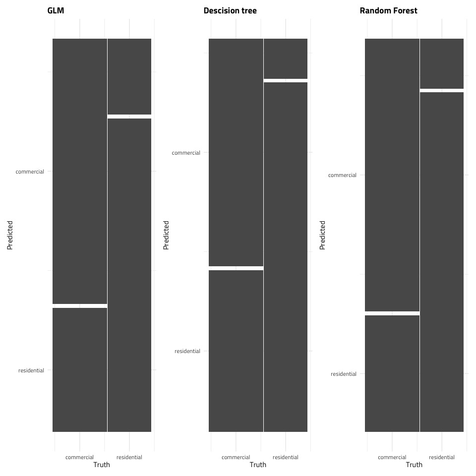

```r
p_cm_glm + p_cm_tree + p_cm_rf
```

```r
p2_cm_glm<- autoplot(cm_glm, type = "heatmap") +
  my_theme +
  labs(title = "GLM")

p2_cm_tree<- autoplot(cm_tree, type = "heatmap") +
  my_theme +
  labs(title = "Descision tree")

p2_cm_rf<- autoplot(cm_rf, type = "heatmap") +
  my_theme +
  labs(title = "Random Forest")
```

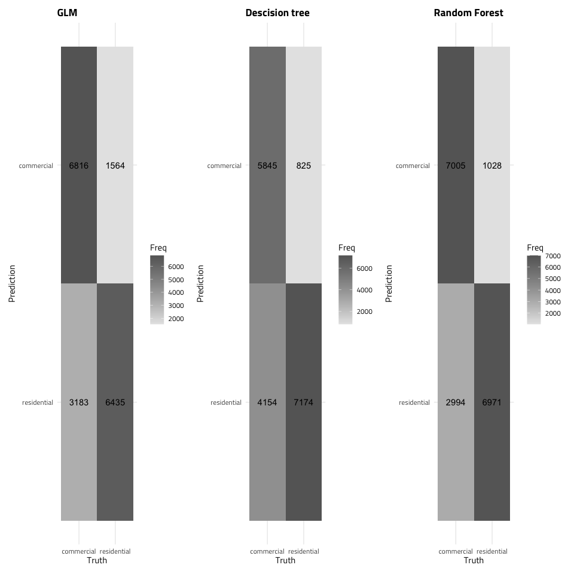

```r
p2_cm_glm + p2_cm_tree + p2_cm_rf
```

```r
t_out<- metrics %>%
  select(-.estimator) %>%
  rename(Metric = ".metric", Estimate = ".estimate") %>%
  group_by(model) %>%
  gt
```

```r
t_out
```

| Metric | Estimate |
| --- | --- |
| GLM |  |
| accuracy | 0.7362485 |
| ppv | 0.8133652 |
| npv | 0.6690580 |
| DecisionTree |  |
| accuracy | 0.7233582 |
| ppv | 0.8763118 |
| npv | 0.6332980 |
| RandomForest |  |
| accuracy | 0.7765307 |
| ppv | 0.8720279 |
| npv | 0.6995484 |

To extract other useful information such as cell counts, we need to approach the data differently. We need to apply gating strategies to discern noise from signal.

#### Useful links

https://juliasilge.com/

https://en.wikipedia.org/wiki/Positive_and_negative_predictive_values

https://www.analyticsvidhya.com/blog/2020/05/decision-tree-vs-random-forest-algorithm/

https://stackoverflow.com/questions/42630248/collapsing-hiding-figures-in-r-markdown